# L01 Introduction

Data Visualization (STAT 302)

INSTRUCTIONS

**TipGithub Repo Link**

A link to your GitHub repo should be placed at the top your submitted html.

## Goals

1. Ensure software for this course is properly installed and functional
2. Understand the importance of visualization
3. Develop and follow a proper workflow
4. Construct and explore a few plots using `ggplot2`
5. Add layers to a plot that include title, axis, and pre-set themes

**Don’t worry if you cannot do everything here by yourself.** You are just getting started and the learning curve is steep, but remember that the instructional team and your classmates will be there to provide support. Persevere and put forth an honest effort and this course will payoff.

**TipOrganization is important!**

1. All packages should always be loaded at the TOP of the document.
2. All data should be in your `data/` subdirectory. Data loading should go at the top of the document under the libraries.

## Tasks

Complete the following tasks and **include some indication that you have completed each** in your document.

### Task 1

Download and install [R Software](https://cran.r-project.org/) **version 4.5.3**.

- If you’ve previously installed R with version < 4.5.3, uninstall the old version first.
- Windows users: [direct link](https://cran.r-project.org/bin/windows/base/R-4.5.3-win.exe)
- Mac users
  - Intel Mac: [direct link](https://cran.r-project.org/bin/macosx/big-sur-x86_64/base/R-4.5.3-x86_64.pkg)
  - Apple Silicon (M1, M2, etc.): [direct link](https://cran.r-project.org/bin/macosx/big-sur-arm64/base/R-4.5.3-arm64.pkg)

### Task 2

1. Download and install [RStudio](https://posit.co/download/rstudio-desktop/).
   - Windows users: [direct link](https://download1.rstudio.org/electron/windows/RStudio-2026.01.1-403.exe)
   - Mac users: [direct link](https://download1.rstudio.org/electron/macos/RStudio-2026.01.1-403.dmg)
2. Open RStudio and ensure it and R have been properly installed.
3. Go to **Tools** > **Global Options** and change the two indicated settings below and click **Apply**. Your other options are likely different than what is pictured. This is okay and we suggest you leave them as is until you become more familiar with RStudio.

[figure not shown]

### Task 3

Install the following packages:

- `tidyverse`, actually it is a collection/universe of packages being installed
- `skimr`
- `devtools`

Easiest method: run the following code in RStudio’s console

```r
install.packages(c("tidyverse", "skimr", "devtools"))
```

### Task 4a

Create a [GitHub](http://github.com/signup) account.

### Task 4b

Install Git. If needed, see [Chapter 6 of Happy Git and GitHub for the useR](https://happygitwithr.com/install-git) for a detailed instruction.

- Windows users
  - Download and install [Git for Windows](https://git-scm.com/install/windows)
  - **NOTE:** When asked about “Adjusting your PATH environment”, make sure to select “Git from the command line and also from 3rd-party software”.
- Mac users
  - Open the **Terminal** app on your computer
  - Run this command in Terminal: `xcode-select --install`
    - Accept the offer! Click on “Install”.

Once you successfully installed Git, double-check following [6.1 - Git already installed?](https://happygitwithr.com/install-git#git-already-installed).

### Task 4c

Introduce yourself to Git. In the terminal, substitute your name and **the email associated with your GitHub account**, and run

```bash
git config --global user.name "Jane Doe"
git config --global user.email "jane@example.com"
```

Double-check using the following command line

```bash
git config --global --list
```

### Task 4d

Once Task 4a-4c are done, we need to connect our local Git with GitHub, the remote Git server. To do so, we need to create a credential (**personal access token or PAT**) and have Git memorizes it.

In RStudio’s console, type and run

```r
usethis::create_github_token()
```

Go back to RStudio’s console. Type and run

```r
gitcreds::gitcreds_set()
```

Paste the PAT in response to the dialogue in the console:

```bash
? Enter password or token: ghp_xxxxxxxxxxxxxxxxxxxxxxxxxxxxxxxxxxxx
-> Adding new credentials...
-> Removing credentials from cache...
-> Done.
```

### Task 5

Since organization is essential for any data science project or work, we should begin by setting up an organizational structure for this course and its contents.

0. Setup a directory/folder on your laptop that will contain all your materials and work for this course. You may already have one setup and named. We will setup this directory and call it `stat-302`. Where this is located on your laptop is completely up to you.
1. Within `stat-302/`, place a copy of the course syllabus for future reference. We also will create a new sub-directory that will contain all labs for this course. For ease let us call it `labs`. So now we have `stat-302/labs/`.
2. Open RStudio and create a “New Project” using “Version Control” -> “Git”
3. Copy the URL from GitHub. Browse so that you place this project within the `stat-302/labs/` folder that you created.
4. Rename `template_L00.qmd` to your `Lastname_Firstname_L00.qmd`
5. Render the file with `Cmd/Ctrl + Shift + K` or click the **Render button**.

### Task 6

Take some time to explore the [Quarto](https://quarto.org/) and [ggplot2](https://ggplot2.tidyverse.org/index.html) websites. We suggest bookmarking them because they will be extremely useful references.

We highly recommend reading through the [Tutorial: Hello, Quarto](https://quarto.org/docs/get-started/hello/rstudio.html).

### Task 7 (optional)

If you are new to RStudio we strongly recommend reading through Chapters 1-4 of the [Stat 202 text book](https://nustat.github.io/intro-stat-data-sci/)

## Exercise 1

Let’s delve into why data visualizations are important.

### Visualization 1

Read the following article and answer the following questions.

[bars_vs_grocery_stores](https://flowingdata.com/2014/05/29/bars-versus-grocery-stores-around-the-world/)

1. List one thing you learned from the article?

**TipSolution**

2. How did the main visualization (United States) enhance the article?

**TipSolution**

3. List at least one thing you liked about the [United States] graphic and one thing you think could be improved.

**TipSolution**

### Visualization 2

Open this [dashboard](https://edgarruiz.shinyapps.io/db-dashboard/) and answer the following questions.

1. What story is this dashboard telling and how do the visualizations enhance that?

**TipSolution**

2. What might a dashboard provide that a static graphic cannot.

**TipSolution**

## Exercise 2

Let’s look at some interesting patterns in the history of LEGO! We’ll be using data taken from the [`lego` package](https://github.com/seankross/lego). A copy of the data is located here `data/legosets.rda`.

First, let’s look at the average cost of LEGO sets over time. The main variable of interest here is `USD_MSRP`, or the manufacturer’s suggested retail price in constant dollars. Let’s recreate the following graphic.

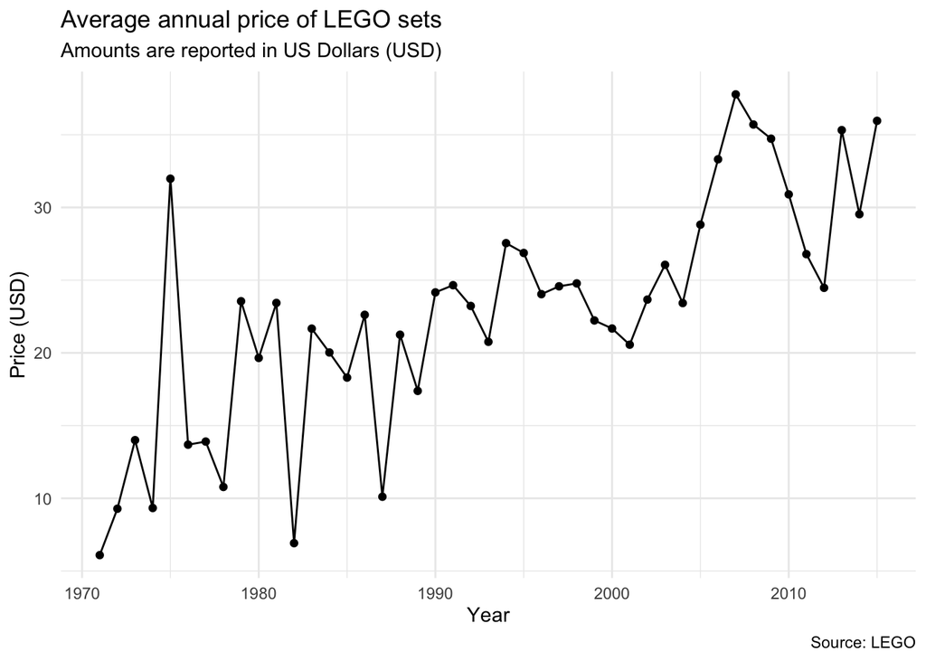

**TipSolution**

## Exercise 3

Let’s explore how many unique themes LEGO now offers.

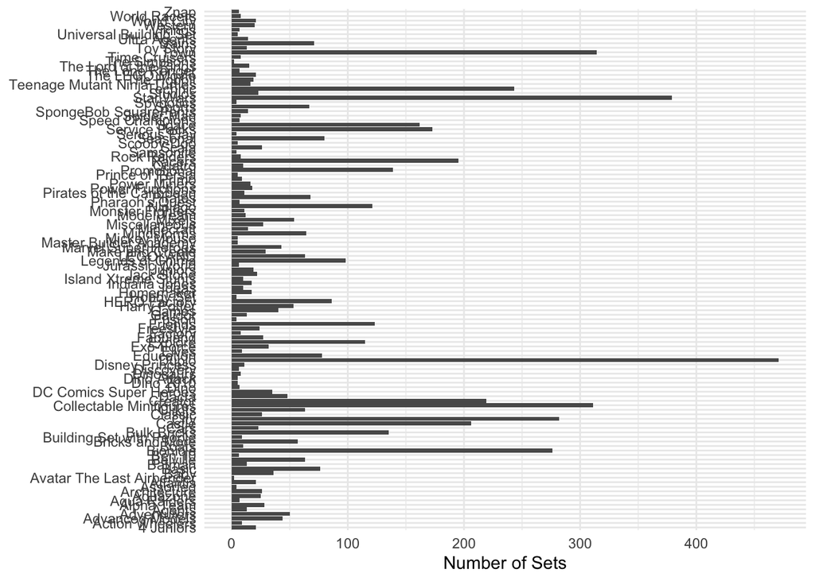

What is bad/ugly about the plot above?

**TipSolution**

Now remake the plot BUT with the improvements addressing the issues you noted above.

**TipSolution**

## Exercise 4

Now you try, let’s look at how the number of pieces per set has changed over time. Because Duplo sets are much smaller (since they’re designed for toddlers), we made a special indicator variable for them in the code below.

```r
pieces_per_year <- legosets |>
  # new indicator variable
  mutate(Duplo = if_else(Theme == "Duplo", "Duplo", "Lego")) |>
  # group_by() both year and Duplo
  # summarize() mean pieces
```

Use an appropriate graph to plot the number of pieces over time. Have either separate lines or separate plots for the Duplo and Lego categories. Be sure the title, x-axis, and y-axis are properly labeled. Add a pre-set theme to make the background look nicer.

What trends do you notice in the plots? Are you surprised by the plots?

**TipSolution**